# 2018402189

# IE 508 Data Project

```r
setwd("/Users/alicansahin/Desktop/BOUN/4.sınıf/2.Dönem/IE 508/Project/FinalDataProject2023")
```

# Q1

## Data Preparing

```r
load("BostonHousing.RData")
set.seed(2018402189)
BH<-Boston[sample(1:dim(Boston)[1],200),]
rownames(BH)<-NULL
```

```r
summary(BH)
```

```
      CRIM                ZN             INDUS             CHAS
 Min.   : 0.00906   Min.   :  0.00   Min.   : 1.250   Min.   :0.000
 1st Qu.: 0.09206   1st Qu.:  0.00   1st Qu.: 5.860   1st Qu.:0.000
 Median : 0.29106   Median :  0.00   Median : 9.795   Median :0.000
 Mean   : 3.17216   Mean   : 11.27   Mean   :11.446   Mean   :0.075
 3rd Qu.: 3.68290   3rd Qu.: 12.50   3rd Qu.:18.100   3rd Qu.:0.000
 Max.   :51.13580   Max.   :100.00   Max.   :27.740   Max.   :1.000
      NOX               RM             AGE              DIS
 Min.   :0.3890   Min.   :4.138   Min.   :  6.00   Min.   : 1.137
 1st Qu.:0.4477   1st Qu.:5.856   1st Qu.: 42.50   1st Qu.: 2.083
 Median :0.5380   Median :6.157   Median : 76.50   Median : 3.239
 Mean   :0.5544   Mean   :6.233   Mean   : 67.89   Mean   : 3.910
 3rd Qu.:0.6240   3rd Qu.:6.547   3rd Qu.: 94.17   3rd Qu.: 5.405
 Max.   :0.8710   Max.   :8.704   Max.   :100.00   Max.   :10.710
      RAD              TAX           PTRATIO            B
 Min.   : 1.000   Min.   :188.0   Min.   :12.60   Min.   :  2.6
 1st Qu.: 4.000   1st Qu.:287.0   1st Qu.:17.40   1st Qu.:376.1
 Median : 5.000   Median :332.0   Median :19.15   Median :391.8
 Mean   : 9.745   Mean   :415.5   Mean   :18.55   Mean   :358.2
 3rd Qu.:24.000   3rd Qu.:666.0   3rd Qu.:20.20   3rd Qu.:395.2
 Max.   :24.000   Max.   :711.0   Max.   :22.00   Max.   :396.9
     LSTAT             MEDV
 Min.   : 1.730   Min.   : 6.30
 1st Qu.: 7.723   1st Qu.:17.10
 Median :12.430   Median :20.65
 Mean   :13.105   Mean   :21.81
 3rd Qu.:17.280   3rd Qu.:24.30
 Max.   :37.970   Max.   :50.00
```

```r
BH$CHAS = as.factor(BH$CHAS)
```

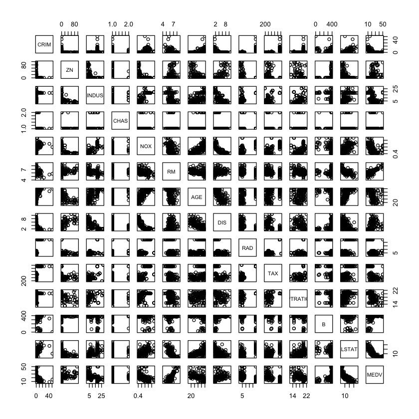

```r
plot(BH)
```

## Model Preparing - Part A

```
Call:
lm(formula = MEDV ~ ., data = BH)

Residuals:
     Min       1Q   Median       3Q      Max
-11.2087  -2.1593  -0.2085   1.4213  16.8258

Coefficients:
              Estimate Std. Error t value Pr(>|t|)
(Intercept)  19.418749   7.270377   2.671 0.008234 **
CRIM         -0.028526   0.068375  -0.417 0.677014
ZN            0.027407   0.018593   1.474 0.142154
INDUS         0.077991   0.086025   0.907 0.365787
CHAS1         1.571255   1.095398   1.434 0.153133
NOX         -12.979848   5.040451  -2.575 0.010797 *
RM            5.073704   0.633093   8.014 1.19e-13 ***
AGE          -0.001829   0.017994  -0.102 0.919128
DIS          -1.049956   0.268018  -3.917 0.000126 ***
RAD           0.195141   0.087470   2.231 0.026880 *
TAX          -0.011309   0.005046  -2.241 0.026183 *
PTRATIO      -0.844603   0.167393  -5.046 1.07e-06 ***
B             0.016176   0.003666   4.413 1.72e-05 ***
LSTAT        -0.486111   0.073257  -6.636 3.43e-10 ***
---
Signif. codes:  0 ‘***’ 0.001 ‘**’ 0.01 ‘*’ 0.05 ‘.’ 0.1 ‘ ’ 1

Residual standard error: 3.933 on 186 degrees of freedom
Multiple R-squared:  0.8041,	Adjusted R-squared:  0.7905
F-statistic: 58.74 on 13 and 186 DF,  p-value: < 2.2e-16
```

1130.78475737151

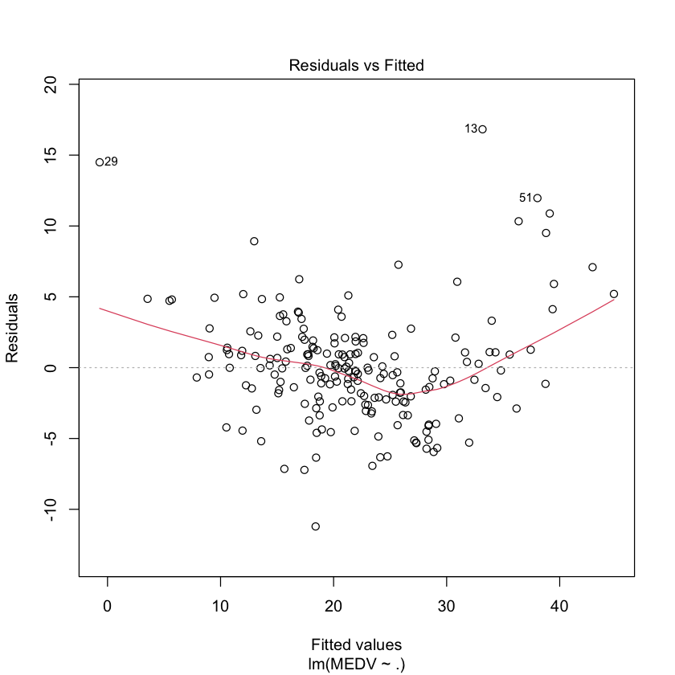

```r
model_all = lm(MEDV~.,data = BH)
summary(model_all)
plot(model_all,1)
AIC(model_all)
```

```r
AIC(glm(MEDV~.,family = Gamma(link=log),BH))
AIC(glm(MEDV~.,family = Gamma(link=identity),BH))
```

1071.00901195999

1136.22006642857

Here, two different models are tried. First model is lm model and the second one is glm with family gamma and link function log. The lm model do not satisfy its conditions. Here, the mean of residuals are not zero and their variances seems not to be constant. To compare the full model with the glm model its AIC values is obtained. When it is compared to gamma model, it can be seen that the AIC value of the glm with gamma model is less. Also, different link functions for gamma family also tried and it is decided to use the glm model with family gamma and link function log.Later on, assumptions of the glm with family gamma also be investigated.

```r
model_gamma = glm(MEDV~.,family = Gamma(link = log),BH)
summary(model_gamma)
```

```
Call:
glm(formula = MEDV ~ ., family = Gamma(link = log), data = BH)

Deviance Residuals:
     Min        1Q    Median        3Q       Max
-0.69708  -0.08844  -0.01543   0.07867   0.70373

Coefficients:
              Estimate Std. Error t value Pr(>|t|)
(Intercept)  3.5999309  0.3077454  11.698  < 2e-16 ***
CRIM        -0.0062617  0.0028942  -2.164 0.031775 *
ZN           0.0007159  0.0007870   0.910 0.364172
INDUS        0.0039944  0.0036413   1.097 0.274082
CHAS1        0.1058545  0.0463667   2.283 0.023562 *
NOX         -0.7201170  0.2133556  -3.375 0.000898 ***
RM           0.1144943  0.0267980   4.273 3.08e-05 ***
AGE          0.0005233  0.0007616   0.687 0.492926
DIS         -0.0372029  0.0113448  -3.279 0.001242 **
RAD          0.0096403  0.0037025   2.604 0.009966 **
TAX         -0.0004663  0.0002136  -2.183 0.030285 *
PTRATIO     -0.0329991  0.0070855  -4.657 6.09e-06 ***
B            0.0007714  0.0001552   4.972 1.50e-06 ***
LSTAT       -0.0296273  0.0031009  -9.554  < 2e-16 ***
---
Signif. codes:  0 ‘***’ 0.001 ‘**’ 0.01 ‘*’ 0.05 ‘.’ 0.1 ‘ ’ 1

(Dispersion parameter for Gamma family taken to be 0.02770995)

    Null deviance: 29.0859  on 199  degrees of freedom
Residual deviance:  5.1653  on 186  degrees of freedom
AIC: 1071

Number of Fisher Scoring iterations: 6
```

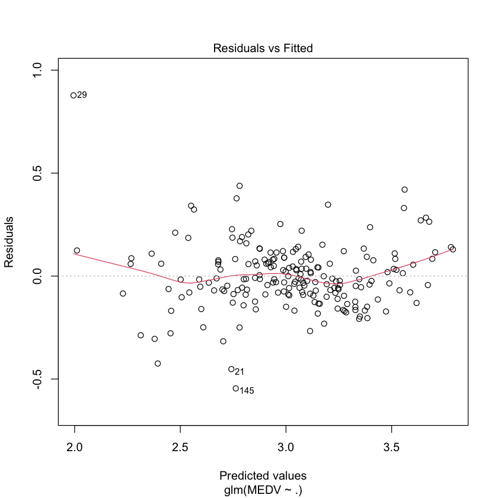

```r
plot(model_gamma,1)
```

Residual plot shows that mean of the residulas do not satify the condition. Therefore, squares of some covarites are added to the model considering the decreases in AIC values

```r
model_gamma = glm(MEDV~.+ I(RM^2) + I(CRIM^2) ,family = Gamma(link = log),BH)
summary(model_gamma)
```

```
Call:
glm(formula = MEDV ~ . + I(RM^2) + I(CRIM^2), family = Gamma(link = log),
    data = BH)

Deviance Residuals:
     Min        1Q    Median        3Q       Max
-0.54116  -0.08947  -0.00988   0.07456   0.41929

Coefficients:
              Estimate Std. Error t value Pr(>|t|)
(Intercept)  7.939e+00  6.775e-01  11.718  < 2e-16 ***
CRIM        -3.553e-02  8.160e-03  -4.354 2.21e-05 ***
ZN           5.705e-04  6.868e-04   0.831 0.407258
INDUS        6.653e-03  3.182e-03   2.091 0.037928 *
CHAS1        1.396e-01  4.089e-02   3.415 0.000784 ***
NOX         -6.694e-01  1.873e-01  -3.574 0.000449 ***
RM          -1.312e+00  2.004e-01  -6.544 5.76e-10 ***
AGE         -4.608e-05  6.702e-04  -0.069 0.945255
DIS         -2.744e-02  9.966e-03  -2.754 0.006483 **
RAD          1.593e-02  3.706e-03   4.298 2.78e-05 ***
TAX         -4.055e-04  1.853e-04  -2.188 0.029926 *
PTRATIO     -2.312e-02  6.304e-03  -3.668 0.000320 ***
B            5.520e-04  1.371e-04   4.026 8.29e-05 ***
LSTAT       -2.891e-02  3.030e-03  -9.542  < 2e-16 ***
I(RM^2)      1.109e-01  1.533e-02   7.234 1.23e-11 ***
I(CRIM^2)    5.409e-04  1.624e-04   3.331 0.001045 **
---
Signif. codes:  0 ‘***’ 0.001 ‘**’ 0.01 ‘*’ 0.05 ‘.’ 0.1 ‘ ’ 1

(Dispersion parameter for Gamma family taken to be 0.02081422)

    Null deviance: 29.0859  on 199  degrees of freedom
Residual deviance:  3.9027  on 184  degrees of freedom
AIC: 1018.7

Number of Fisher Scoring iterations: 5
```

As it can be seen, the AIC values decreases tremendously, and added values has significance on the response. From this point on insignifacant covariates are removed from the model considering the AIC value. After AIC value starts to increase we stopped.

```r
model_gamma = glm(MEDV~.+ I(RM^2) + I(CRIM^2)-AGE ,family = Gamma(link = log),BH)
summary(model_gamma)
```

```
Call:
glm(formula = MEDV ~ . + I(RM^2) + I(CRIM^2) - AGE, family = Gamma(link = log),
    data = BH)

Deviance Residuals:
     Min        1Q    Median        3Q       Max
-0.54143  -0.08996  -0.00943   0.07449   0.41847

Coefficients:
              Estimate Std. Error t value Pr(>|t|)
(Intercept)  7.9395282  0.6756343  11.751  < 2e-16 ***
CRIM        -0.0354542  0.0080502  -4.404 1.79e-05 ***
ZN           0.0005762  0.0006803   0.847 0.398049
INDUS        0.0066533  0.0031728   2.097 0.037358 *
CHAS1        0.1393876  0.0406583   3.428 0.000749 ***
NOX         -0.6730112  0.1788302  -3.763 0.000225 ***
RM          -1.3112806  0.1997608  -6.564 5.11e-10 ***
DIS         -0.0272726  0.0096035  -2.840 0.005019 **
RAD          0.0159488  0.0036831   4.330 2.44e-05 ***
TAX         -0.0004068  0.0001838  -2.213 0.028091 *
PTRATIO     -0.0231646  0.0062552  -3.703 0.000281 ***
B            0.0005513  0.0001361   4.051 7.51e-05 ***
LSTAT       -0.0289988  0.0027304 -10.621  < 2e-16 ***
I(RM^2)      0.1108010  0.0152496   7.266 1.00e-11 ***
I(CRIM^2)    0.0005392  0.0001597   3.376 0.000897 ***
---
Signif. codes:  0 ‘***’ 0.001 ‘**’ 0.01 ‘*’ 0.05 ‘.’ 0.1 ‘ ’ 1

(Dispersion parameter for Gamma family taken to be 0.0207004)

    Null deviance: 29.0859  on 199  degrees of freedom
Residual deviance:  3.9028  on 185  degrees of freedom
AIC: 1016.7

Number of Fisher Scoring iterations: 5
```

```r
model_gamma = glm(MEDV~.+ I(RM^2) + I(CRIM^2)-AGE-ZN ,family = Gamma(link = log),BH)
summary(model_gamma)
```

```
Call:
glm(formula = MEDV ~ . + I(RM^2) + I(CRIM^2) - AGE - ZN, family = Gamma(link = log),
    data = BH)

Deviance Residuals:
     Min        1Q    Median        3Q       Max
-0.54218  -0.09199  -0.01011   0.07688   0.41563

Coefficients:
              Estimate Std. Error t value Pr(>|t|)
(Intercept)  7.9718205  0.6738823  11.830  < 2e-16 ***
CRIM        -0.0345293  0.0079587  -4.339 2.35e-05 ***
INDUS        0.0061194  0.0031158   1.964 0.051024 .
CHAS1        0.1394714  0.0406094   3.434 0.000732 ***
NOX         -0.6834930  0.1781723  -3.836 0.000171 ***
RM          -1.3180862  0.1994044  -6.610 3.94e-10 ***
DIS         -0.0239381  0.0087183  -2.746 0.006630 **
RAD          0.0152109  0.0035848   4.243 3.47e-05 ***
TAX         -0.0003547  0.0001741  -2.037 0.043057 *
PTRATIO     -0.0246878  0.0059735  -4.133 5.41e-05 ***
B            0.0005511  0.0001359   4.054 7.40e-05 ***
LSTAT       -0.0290949  0.0027239 -10.681  < 2e-16 ***
I(RM^2)      0.1115267  0.0152129   7.331 6.79e-12 ***
I(CRIM^2)    0.0005241  0.0001584   3.308 0.001127 **
---
Signif. codes:  0 ‘***’ 0.001 ‘**’ 0.01 ‘*’ 0.05 ‘.’ 0.1 ‘ ’ 1

(Dispersion parameter for Gamma family taken to be 0.0206506)

    Null deviance: 29.0859  on 199  degrees of freedom
Residual deviance:  3.9177  on 186  degrees of freedom
AIC: 1015.5

Number of Fisher Scoring iterations: 5
```

From that point, the AIC value starts to increase. Therefore, this model becomes our final model.

```r
#model_gamma = glm(MEDV~.+ I(RM^2) + I(CRIM^2)-AGE-ZN-INDUS ,family = Gamma(link = log),BH)
#summary(model_gamma)
```

```
Call:
glm(formula = MEDV ~ . + I(RM^2) + I(CRIM^2) - AGE - ZN - INDUS,
    family = Gamma(link = log), data = BH)

Deviance Residuals:
     Min        1Q    Median        3Q       Max
-0.54457  -0.09125  -0.00588   0.06975   0.42069

Coefficients:
              Estimate Std. Error t value Pr(>|t|)
(Intercept)  7.8585281  0.6752495  11.638  < 2e-16 ***
CRIM        -0.0353831  0.0079854  -4.431 1.60e-05 ***
CHAS1        0.1389533  0.0408333   3.403 0.000815 ***
NOX         -0.6161694  0.1760706  -3.500 0.000583 ***
RM          -1.2734760  0.1991948  -6.393 1.26e-09 ***
DIS         -0.0312185  0.0079294  -3.937 0.000116 ***
RAD          0.0137758  0.0035354   3.897 0.000136 ***
TAX         -0.0001920  0.0001539  -1.247 0.213806
PTRATIO     -0.0251203  0.0060029  -4.185 4.39e-05 ***
B            0.0005505  0.0001367   4.027 8.19e-05 ***
LSTAT       -0.0285751  0.0027262 -10.482  < 2e-16 ***
I(RM^2)      0.1076171  0.0151618   7.098 2.55e-11 ***
I(CRIM^2)    0.0005373  0.0001591   3.378 0.000890 ***
---
Signif. codes:  0 ‘***’ 0.001 ‘**’ 0.01 ‘*’ 0.05 ‘.’ 0.1 ‘ ’ 1

(Dispersion parameter for Gamma family taken to be 0.02088122)

    Null deviance: 29.0859  on 199  degrees of freedom
Residual deviance:  3.9993  on 187  degrees of freedom
AIC: 1017.6

Number of Fisher Scoring iterations: 5
```

## Part B

```r
first20 = BH[1:20,]
first20
```

A data.frame: 20 × 14

|  | CRIM <dbl> | ZN <dbl> | INDUS <dbl> | CHAS <fct> | NOX <dbl> | RM <dbl> | AGE <dbl> | DIS <dbl> | RAD <int> | TAX <dbl> | PTRATIO <dbl> | B <dbl> | LSTAT <dbl> | MEDV <dbl> |
| --- | --- | --- | --- | --- | --- | --- | --- | --- | --- | --- | --- | --- | --- | --- |
| 1 | 13.07510 | 0 | 18.10 | 0 | 0.580 | 5.713 | 56.7 | 2.8237 | 24 | 666 | 20.2 | 396.90 | 14.76 | 20.1 |
| 2 | 0.40771 | 0 | 6.20 | 1 | 0.507 | 6.164 | 91.3 | 3.0480 | 8 | 307 | 17.4 | 395.24 | 21.46 | 21.7 |
| 3 | 0.29916 | 20 | 6.96 | 0 | 0.464 | 5.856 | 42.1 | 4.4290 | 3 | 223 | 18.6 | 388.65 | 13.00 | 21.1 |
| 4 | 0.11132 | 0 | 27.74 | 0 | 0.609 | 5.983 | 83.5 | 2.1099 | 4 | 711 | 20.1 | 396.90 | 13.35 | 20.1 |
| 5 | 0.09299 | 0 | 25.65 | 0 | 0.581 | 5.961 | 92.9 | 2.0869 | 2 | 188 | 19.1 | 378.09 | 17.93 | 20.5 |
| 6 | 0.10612 | 30 | 4.93 | 0 | 0.428 | 6.095 | 65.1 | 6.3361 | 6 | 300 | 16.6 | 394.62 | 12.40 | 20.1 |
| 7 | 0.15086 | 0 | 27.74 | 0 | 0.609 | 5.454 | 92.7 | 1.8209 | 4 | 711 | 20.1 | 395.09 | 18.06 | 15.2 |
| 8 | 4.81213 | 0 | 18.10 | 0 | 0.713 | 6.701 | 90.0 | 2.5975 | 24 | 666 | 20.2 | 255.23 | 16.42 | 16.4 |
| 9 | 9.91655 | 0 | 18.10 | 0 | 0.693 | 5.852 | 77.8 | 1.5004 | 24 | 666 | 20.2 | 338.16 | 29.97 | 6.3 |
| 10 | 0.14231 | 0 | 10.01 | 0 | 0.547 | 6.254 | 84.2 | 2.2565 | 6 | 432 | 17.8 | 388.74 | 10.45 | 18.5 |
| 11 | 1.13081 | 0 | 8.14 | 0 | 0.538 | 5.713 | 94.1 | 4.2330 | 4 | 307 | 21.0 | 360.17 | 22.60 | 12.7 |
| 12 | 0.01778 | 95 | 1.47 | 0 | 0.403 | 7.135 | 13.9 | 7.6534 | 3 | 402 | 17.0 | 384.30 | 4.45 | 32.9 |
| 13 | 6.53876 | 0 | 18.10 | 1 | 0.631 | 7.016 | 97.5 | 1.2024 | 24 | 666 | 20.2 | 392.05 | 2.96 | 50.0 |
| 14 | 0.04819 | 80 | 3.64 | 0 | 0.392 | 6.108 | 32.0 | 9.2203 | 1 | 315 | 16.4 | 392.89 | 6.57 | 21.9 |
| 15 | 0.14150 | 0 | 6.91 | 0 | 0.448 | 6.169 | 6.6 | 5.7209 | 3 | 233 | 17.9 | 383.37 | 5.81 | 25.3 |
| 16 | 0.05735 | 0 | 4.49 | 0 | 0.449 | 6.630 | 56.1 | 4.4377 | 3 | 247 | 18.5 | 392.30 | 6.53 | 26.6 |
| 17 | 0.21977 | 0 | 6.91 | 0 | 0.448 | 5.602 | 62.0 | 6.0877 | 3 | 233 | 17.9 | 396.90 | 16.20 | 19.4 |
| 18 | 2.81838 | 0 | 18.10 | 0 | 0.532 | 5.762 | 40.3 | 4.0983 | 24 | 666 | 20.2 | 392.92 | 10.42 | 21.8 |
| 19 | 5.58107 | 0 | 18.10 | 0 | 0.713 | 6.436 | 87.9 | 2.3158 | 24 | 666 | 20.2 | 100.19 | 16.22 | 14.3 |
| 20 | 0.05644 | 40 | 6.41 | 1 | 0.447 | 6.758 | 32.9 | 4.0776 | 4 | 254 | 17.6 | 396.90 | 3.53 | 32.4 |

```r
dispersion = 0.0206506
alpha = 1/dispersion
predictions = exp(predict(model_gamma,first20))
beta = predictions * dispersion
lb = qgamma(0.1,shape = alpha,scale = beta)
upper = qgamma(0.9,shape = alpha,scale = beta)
```

```r
first20AllPred = first20
first20AllPred$lwr = lb
first20AllPred$fit = predictions
first20AllPred$upr = upper
first20AllPred
```

A data.frame: 20 × 17

|  | CRIM <dbl> | ZN <dbl> | INDUS <dbl> | CHAS <fct> | NOX <dbl> | RM <dbl> | AGE <dbl> | DIS <dbl> | RAD <int> | TAX <dbl> | PTRATIO <dbl> | B <dbl> | LSTAT <dbl> | MEDV <dbl> | lwr <dbl> | fit <dbl> | upr <dbl> |
| --- | --- | --- | --- | --- | --- | --- | --- | --- | --- | --- | --- | --- | --- | --- | --- | --- | --- |
| 1 | 13.07510 | 0 | 18.10 | 0 | 0.580 | 5.713 | 56.7 | 2.8237 | 24 | 666 | 20.2 | 396.90 | 14.76 | 20.1 | 13.309032 | 16.21426 | 19.26281 |
| 2 | 0.40771 | 0 | 6.20 | 1 | 0.507 | 6.164 | 91.3 | 3.0480 | 8 | 307 | 17.4 | 395.24 | 21.46 | 21.7 | 16.571742 | 20.18918 | 23.98509 |
| 3 | 0.29916 | 20 | 6.96 | 0 | 0.464 | 5.856 | 42.1 | 4.4290 | 3 | 223 | 18.6 | 388.65 | 13.00 | 21.1 | 16.990060 | 20.69881 | 24.59054 |
| 4 | 0.11132 | 0 | 27.74 | 0 | 0.609 | 5.983 | 83.5 | 2.1099 | 4 | 711 | 20.1 | 396.90 | 13.35 | 20.1 | 15.216194 | 18.53773 | 22.02314 |
| 5 | 0.09299 | 0 | 25.65 | 0 | 0.581 | 5.961 | 92.9 | 2.0869 | 2 | 188 | 19.1 | 378.09 | 17.93 | 20.5 | 15.891084 | 19.35994 | 22.99994 |
| 6 | 0.10612 | 30 | 4.93 | 0 | 0.428 | 6.095 | 65.1 | 6.3361 | 6 | 300 | 16.6 | 394.62 | 12.40 | 20.1 | 18.133368 | 22.09170 | 26.24531 |
| 7 | 0.15086 | 0 | 27.74 | 0 | 0.609 | 5.454 | 92.7 | 1.8209 | 4 | 711 | 20.1 | 395.09 | 18.06 | 15.2 | 13.631677 | 16.60733 | 19.72979 |
| 8 | 4.81213 | 0 | 18.10 | 0 | 0.713 | 6.701 | 90.0 | 2.5975 | 24 | 666 | 20.2 | 255.23 | 16.42 | 16.4 | 14.154749 | 17.24459 | 20.48686 |
| 9 | 9.91655 | 0 | 18.10 | 0 | 0.693 | 5.852 | 77.8 | 1.5004 | 24 | 666 | 20.2 | 338.16 | 29.97 | 6.3 | 8.457517 | 10.30371 | 12.24098 |
| 10 | 0.14231 | 0 | 10.01 | 0 | 0.547 | 6.254 | 84.2 | 2.2565 | 6 | 432 | 17.8 | 388.74 | 10.45 | 18.5 | 18.734503 | 22.82405 | 27.11536 |
| 11 | 1.13081 | 0 | 8.14 | 0 | 0.538 | 5.713 | 94.1 | 4.2330 | 4 | 307 | 21.0 | 360.17 | 22.60 | 12.7 | 11.034278 | 13.44295 | 15.97045 |
| 12 | 0.01778 | 95 | 1.47 | 0 | 0.403 | 7.135 | 13.9 | 7.6534 | 3 | 402 | 17.0 | 384.30 | 4.45 | 32.9 | 23.636986 | 28.79670 | 34.21096 |
| 13 | 6.53876 | 0 | 18.10 | 1 | 0.631 | 7.016 | 97.5 | 1.2024 | 24 | 666 | 20.2 | 392.05 | 2.96 | 50.0 | 28.885022 | 35.19033 | 41.80670 |
| 14 | 0.04819 | 80 | 3.64 | 0 | 0.392 | 6.108 | 32.0 | 9.2203 | 1 | 315 | 16.4 | 392.89 | 6.57 | 21.9 | 18.919778 | 23.04977 | 27.38352 |
| 15 | 0.14150 | 0 | 6.91 | 0 | 0.448 | 6.169 | 6.6 | 5.7209 | 3 | 233 | 17.9 | 383.37 | 5.81 | 25.3 | 21.009247 | 25.59535 | 30.40771 |
| 16 | 0.05735 | 0 | 4.49 | 0 | 0.449 | 6.630 | 56.1 | 4.4377 | 3 | 247 | 18.5 | 392.30 | 6.53 | 26.6 | 21.708101 | 26.44676 | 31.41919 |
| 17 | 0.21977 | 0 | 6.91 | 0 | 0.448 | 5.602 | 62.0 | 6.0877 | 3 | 233 | 17.9 | 396.90 | 16.20 | 19.4 | 15.512759 | 18.89904 | 22.45237 |
| 18 | 2.81838 | 0 | 18.10 | 0 | 0.532 | 5.762 | 40.3 | 4.0983 | 24 | 666 | 20.2 | 392.92 | 10.42 | 21.8 | 19.720622 | 24.02543 | 28.54262 |
| 19 | 5.58107 | 0 | 18.10 | 0 | 0.713 | 6.436 | 87.9 | 2.3158 | 24 | 666 | 20.2 | 100.19 | 16.22 | 14.3 | 12.377094 | 15.07889 | 17.91397 |
| 20 | 0.05644 | 40 | 6.41 | 1 | 0.447 | 6.758 | 32.9 | 4.0776 | 4 | 254 | 17.6 | 396.90 | 3.53 | 32.4 | 29.550335 | 36.00087 | 42.76964 |

```r
first20AllPred$IsInc = rep(0,20)
first20AllPred[first20AllPred$MEDV < first20AllPred$fit,]$IsInc = 1
first20AllPred
```

A data.frame: 20 × 18

|  | CRIM <dbl> | ZN <dbl> | INDUS <dbl> | CHAS <fct> | NOX <dbl> | RM <dbl> | AGE <dbl> | DIS <dbl> | RAD <int> | TAX <dbl> | PTRATIO <dbl> | B <dbl> | LSTAT <dbl> | MEDV <dbl> | lwr <dbl> | fit <dbl> | upr <dbl> | IsInc <dbl> |
| --- | --- | --- | --- | --- | --- | --- | --- | --- | --- | --- | --- | --- | --- | --- | --- | --- | --- | --- |
| 1 | 13.07510 | 0 | 18.10 | 0 | 0.580 | 5.713 | 56.7 | 2.8237 | 24 | 666 | 20.2 | 396.90 | 14.76 | 20.1 | 13.309032 | 16.21426 | 19.26281 | 0 |
| 2 | 0.40771 | 0 | 6.20 | 1 | 0.507 | 6.164 | 91.3 | 3.0480 | 8 | 307 | 17.4 | 395.24 | 21.46 | 21.7 | 16.571742 | 20.18918 | 23.98509 | 0 |
| 3 | 0.29916 | 20 | 6.96 | 0 | 0.464 | 5.856 | 42.1 | 4.4290 | 3 | 223 | 18.6 | 388.65 | 13.00 | 21.1 | 16.990060 | 20.69881 | 24.59054 | 0 |
| 4 | 0.11132 | 0 | 27.74 | 0 | 0.609 | 5.983 | 83.5 | 2.1099 | 4 | 711 | 20.1 | 396.90 | 13.35 | 20.1 | 15.216194 | 18.53773 | 22.02314 | 0 |
| 5 | 0.09299 | 0 | 25.65 | 0 | 0.581 | 5.961 | 92.9 | 2.0869 | 2 | 188 | 19.1 | 378.09 | 17.93 | 20.5 | 15.891084 | 19.35994 | 22.99994 | 0 |
| 6 | 0.10612 | 30 | 4.93 | 0 | 0.428 | 6.095 | 65.1 | 6.3361 | 6 | 300 | 16.6 | 394.62 | 12.40 | 20.1 | 18.133368 | 22.09170 | 26.24531 | 1 |
| 7 | 0.15086 | 0 | 27.74 | 0 | 0.609 | 5.454 | 92.7 | 1.8209 | 4 | 711 | 20.1 | 395.09 | 18.06 | 15.2 | 13.631677 | 16.60733 | 19.72979 | 1 |
| 8 | 4.81213 | 0 | 18.10 | 0 | 0.713 | 6.701 | 90.0 | 2.5975 | 24 | 666 | 20.2 | 255.23 | 16.42 | 16.4 | 14.154749 | 17.24459 | 20.48686 | 1 |
| 9 | 9.91655 | 0 | 18.10 | 0 | 0.693 | 5.852 | 77.8 | 1.5004 | 24 | 666 | 20.2 | 338.16 | 29.97 | 6.3 | 8.457517 | 10.30371 | 12.24098 | 1 |
| 10 | 0.14231 | 0 | 10.01 | 0 | 0.547 | 6.254 | 84.2 | 2.2565 | 6 | 432 | 17.8 | 388.74 | 10.45 | 18.5 | 18.734503 | 22.82405 | 27.11536 | 1 |
| 11 | 1.13081 | 0 | 8.14 | 0 | 0.538 | 5.713 | 94.1 | 4.2330 | 4 | 307 | 21.0 | 360.17 | 22.60 | 12.7 | 11.034278 | 13.44295 | 15.97045 | 1 |
| 12 | 0.01778 | 95 | 1.47 | 0 | 0.403 | 7.135 | 13.9 | 7.6534 | 3 | 402 | 17.0 | 384.30 | 4.45 | 32.9 | 23.636986 | 28.79670 | 34.21096 | 0 |
| 13 | 6.53876 | 0 | 18.10 | 1 | 0.631 | 7.016 | 97.5 | 1.2024 | 24 | 666 | 20.2 | 392.05 | 2.96 | 50.0 | 28.885022 | 35.19033 | 41.80670 | 0 |
| 14 | 0.04819 | 80 | 3.64 | 0 | 0.392 | 6.108 | 32.0 | 9.2203 | 1 | 315 | 16.4 | 392.89 | 6.57 | 21.9 | 18.919778 | 23.04977 | 27.38352 | 1 |
| 15 | 0.14150 | 0 | 6.91 | 0 | 0.448 | 6.169 | 6.6 | 5.7209 | 3 | 233 | 17.9 | 383.37 | 5.81 | 25.3 | 21.009247 | 25.59535 | 30.40771 | 1 |
| 16 | 0.05735 | 0 | 4.49 | 0 | 0.449 | 6.630 | 56.1 | 4.4377 | 3 | 247 | 18.5 | 392.30 | 6.53 | 26.6 | 21.708101 | 26.44676 | 31.41919 | 0 |
| 17 | 0.21977 | 0 | 6.91 | 0 | 0.448 | 5.602 | 62.0 | 6.0877 | 3 | 233 | 17.9 | 396.90 | 16.20 | 19.4 | 15.512759 | 18.89904 | 22.45237 | 0 |
| 18 | 2.81838 | 0 | 18.10 | 0 | 0.532 | 5.762 | 40.3 | 4.0983 | 24 | 666 | 20.2 | 392.92 | 10.42 | 21.8 | 19.720622 | 24.02543 | 28.54262 | 1 |
| 19 | 5.58107 | 0 | 18.10 | 0 | 0.713 | 6.436 | 87.9 | 2.3158 | 24 | 666 | 20.2 | 100.19 | 16.22 | 14.3 | 12.377094 | 15.07889 | 17.91397 | 1 |
| 20 | 0.05644 | 40 | 6.41 | 1 | 0.447 | 6.758 | 32.9 | 4.0776 | 4 | 254 | 17.6 | 396.90 | 3.53 | 32.4 | 29.550335 | 36.00087 | 42.76964 | 1 |

Here the 4 observations are out of the PI. The others are their PI and fitted values and actual values are similar. The model seems not the best model but overall it can be said that its performance is good. Additional improvements can be made and model can be made better. The houses from which the model expect increase or decrease in MEDV is are shown in IsInc columns. 1 indicates there will be increase the 0 indicate there will be decrease. About 50% of the house will increase.

## Part C

```r
dataExcept20 = BH[-c(1:20),]
```

```r
model_outSample = glm(MEDV~.+ I(RM^2) + I(CRIM^2)-AGE-ZN ,family = Gamma(link = log),dataExcept20)
predictionOutSample = exp(predict(model_outSample,first20))
first20AllPred$predictionOutSample = predictionOutSample
first20AllPred
```

A data.frame: 20 × 19

|  | CRIM <dbl> | ZN <dbl> | INDUS <dbl> | CHAS <fct> | NOX <dbl> | RM <dbl> | AGE <dbl> | DIS <dbl> | RAD <int> | TAX <dbl> | PTRATIO <dbl> | B <dbl> | LSTAT <dbl> | MEDV <dbl> | lwr <dbl> | fit <dbl> | upr <dbl> | IsInc <dbl> | predictionOutSample <dbl> |
| --- | --- | --- | --- | --- | --- | --- | --- | --- | --- | --- | --- | --- | --- | --- | --- | --- | --- | --- | --- |
| 1 | 13.07510 | 0 | 18.10 | 0 | 0.580 | 5.713 | 56.7 | 2.8237 | 24 | 666 | 20.2 | 396.90 | 14.76 | 20.1 | 13.309032 | 16.21426 | 19.26281 | 0 | 15.41923 |
| 2 | 0.40771 | 0 | 6.20 | 1 | 0.507 | 6.164 | 91.3 | 3.0480 | 8 | 307 | 17.4 | 395.24 | 21.46 | 21.7 | 16.571742 | 20.18918 | 23.98509 | 0 | 20.35861 |
| 3 | 0.29916 | 20 | 6.96 | 0 | 0.464 | 5.856 | 42.1 | 4.4290 | 3 | 223 | 18.6 | 388.65 | 13.00 | 21.1 | 16.990060 | 20.69881 | 24.59054 | 0 | 20.88526 |
| 4 | 0.11132 | 0 | 27.74 | 0 | 0.609 | 5.983 | 83.5 | 2.1099 | 4 | 711 | 20.1 | 396.90 | 13.35 | 20.1 | 15.216194 | 18.53773 | 22.02314 | 0 | 18.22597 |
| 5 | 0.09299 | 0 | 25.65 | 0 | 0.581 | 5.961 | 92.9 | 2.0869 | 2 | 188 | 19.1 | 378.09 | 17.93 | 20.5 | 15.891084 | 19.35994 | 22.99994 | 0 | 19.50094 |
| 6 | 0.10612 | 30 | 4.93 | 0 | 0.428 | 6.095 | 65.1 | 6.3361 | 6 | 300 | 16.6 | 394.62 | 12.40 | 20.1 | 18.133368 | 22.09170 | 26.24531 | 1 | 22.58281 |
| 7 | 0.15086 | 0 | 27.74 | 0 | 0.609 | 5.454 | 92.7 | 1.8209 | 4 | 711 | 20.1 | 395.09 | 18.06 | 15.2 | 13.631677 | 16.60733 | 19.72979 | 1 | 16.51473 |
| 8 | 4.81213 | 0 | 18.10 | 0 | 0.713 | 6.701 | 90.0 | 2.5975 | 24 | 666 | 20.2 | 255.23 | 16.42 | 16.4 | 14.154749 | 17.24459 | 20.48686 | 1 | 17.64651 |
| 9 | 9.91655 | 0 | 18.10 | 0 | 0.693 | 5.852 | 77.8 | 1.5004 | 24 | 666 | 20.2 | 338.16 | 29.97 | 6.3 | 8.457517 | 10.30371 | 12.24098 | 1 | 10.69870 |
| 10 | 0.14231 | 0 | 10.01 | 0 | 0.547 | 6.254 | 84.2 | 2.2565 | 6 | 432 | 17.8 | 388.74 | 10.45 | 18.5 | 18.734503 | 22.82405 | 27.11536 | 1 | 23.02064 |
| 11 | 1.13081 | 0 | 8.14 | 0 | 0.538 | 5.713 | 94.1 | 4.2330 | 4 | 307 | 21.0 | 360.17 | 22.60 | 12.7 | 11.034278 | 13.44295 | 15.97045 | 1 | 13.96623 |
| 12 | 0.01778 | 95 | 1.47 | 0 | 0.403 | 7.135 | 13.9 | 7.6534 | 3 | 402 | 17.0 | 384.30 | 4.45 | 32.9 | 23.636986 | 28.79670 | 34.21096 | 0 | 28.63276 |
| 13 | 6.53876 | 0 | 18.10 | 1 | 0.631 | 7.016 | 97.5 | 1.2024 | 24 | 666 | 20.2 | 392.05 | 2.96 | 50.0 | 28.885022 | 35.19033 | 41.80670 | 0 | 31.70947 |
| 14 | 0.04819 | 80 | 3.64 | 0 | 0.392 | 6.108 | 32.0 | 9.2203 | 1 | 315 | 16.4 | 392.89 | 6.57 | 21.9 | 18.919778 | 23.04977 | 27.38352 | 1 | 22.84742 |
| 15 | 0.14150 | 0 | 6.91 | 0 | 0.448 | 6.169 | 6.6 | 5.7209 | 3 | 233 | 17.9 | 383.37 | 5.81 | 25.3 | 21.009247 | 25.59535 | 30.40771 | 1 | 25.21961 |
| 16 | 0.05735 | 0 | 4.49 | 0 | 0.449 | 6.630 | 56.1 | 4.4377 | 3 | 247 | 18.5 | 392.30 | 6.53 | 26.6 | 21.708101 | 26.44676 | 31.41919 | 0 | 26.30695 |
| 17 | 0.21977 | 0 | 6.91 | 0 | 0.448 | 5.602 | 62.0 | 6.0877 | 3 | 233 | 17.9 | 396.90 | 16.20 | 19.4 | 15.512759 | 18.89904 | 22.45237 | 0 | 19.28587 |
| 18 | 2.81838 | 0 | 18.10 | 0 | 0.532 | 5.762 | 40.3 | 4.0983 | 24 | 666 | 20.2 | 392.92 | 10.42 | 21.8 | 19.720622 | 24.02543 | 28.54262 | 1 | 23.78858 |
| 19 | 5.58107 | 0 | 18.10 | 0 | 0.713 | 6.436 | 87.9 | 2.3158 | 24 | 666 | 20.2 | 100.19 | 16.22 | 14.3 | 12.377094 | 15.07889 | 17.91397 | 1 | 15.37891 |
| 20 | 0.05644 | 40 | 6.41 | 1 | 0.447 | 6.758 | 32.9 | 4.0776 | 4 | 254 | 17.6 | 396.90 | 3.53 | 32.4 | 29.550335 | 36.00087 | 42.76964 | 1 | 33.59664 |

```r
mseOutSample = mean((first20AllPred$predictionOutSample - first20AllPred$MEDV)^2)
mseInSample = mean((first20AllPred$fit - first20AllPred$MEDV)^2)
mseOutSample
mseInSample
```

21.9703128649713

15.9797711014876

Out of the sample error is much larger than in the sample error. It tells us that when the model will encounter the new data, that has not been modeled, can give worse results.

# Q2

## Data Preparing

```r
load("CreditCard.RData")
set.seed(2018402189)
CC <- dCC[sample(1:dim(dCC)[1],4000),]
rownames(CC)<-NULL
```

```r
head(CC,2)
summary(CC)
```

A tibble: 2 × 8

|  | sex <dbl> | age <dbl> | limit <dbl> | ps1 <dbl> | ps2 <dbl> | bill1 <dbl> | bill2 <dbl> | default <fct> |
| --- | --- | --- | --- | --- | --- | --- | --- | --- |
| 1 | 2 | 24 | 50000 | 0 | 0 | 26735 | 26994 | 0 |
| 2 | 2 | 27 | 30000 | 0 | 0 | 26951 | 27726 | 0 |

```
      sex             age            limit             ps1
 Min.   :1.000   Min.   :21.00   Min.   : 10000   Min.   :-1.000
 1st Qu.:1.000   1st Qu.:28.00   1st Qu.: 50000   1st Qu.:-1.000
 Median :2.000   Median :34.00   Median :140000   Median : 0.000
 Mean   :1.609   Mean   :35.45   Mean   :167298   Mean   : 0.087
 3rd Qu.:2.000   3rd Qu.:41.00   3rd Qu.:240000   3rd Qu.: 0.000
 Max.   :2.000   Max.   :75.00   Max.   :800000   Max.   : 3.000
      ps2              bill1            bill2        default
 Min.   :-1.0000   Min.   :-14386   Min.   :-13543   0:3089
 1st Qu.:-1.0000   1st Qu.:  3620   1st Qu.:  2691   1: 911
 Median : 0.0000   Median : 22036   Median : 21100
 Mean   :-0.0055   Mean   : 52305   Mean   : 50101
 3rd Qu.: 0.0000   3rd Qu.: 67944   3rd Qu.: 64242
 Max.   : 3.0000   Max.   :626648   Max.   :605943
```

```r
CC$sex = as.factor(CC$sex)
CC$ps1 = as.factor(CC$ps1)
CC$ps2 = as.factor(CC$ps2)
summary(CC)
```

```
 sex           age            limit        ps1       ps2           bill1
 1:1566   Min.   :21.00   Min.   : 10000   -1:1081   -1:1308   Min.   :-14386
 2:2434   1st Qu.:28.00   1st Qu.: 50000   0 :1971   0 :2081   1st Qu.:  3620
          Median :34.00   Median :140000   1 : 534   1 :   2   Median : 22036
          Mean   :35.45   Mean   :167298   2 : 347   2 : 543   Mean   : 52305
          3rd Qu.:41.00   3rd Qu.:240000   3 :  67   3 :  66   3rd Qu.: 67944
          Max.   :75.00   Max.   :800000                       Max.   :626648
     bill2        default
 Min.   :-13543   0:3089
 1st Qu.:  2691   1: 911
 Median : 21100
 Mean   : 50101
 3rd Qu.: 64242
 Max.   :605943
```

## Part A

```r
set.seed(2018402189)
sampleIndex = sample(c(1:dim(CC)[1]),dim(CC)[1]/2,replace = FALSE)
trainSet = CC[sampleIndex,]
testSet = CC[-sampleIndex,]
summary(trainSet)
summary(testSet)
```

```
 sex           age            limit        ps1      ps2           bill1
 1: 754   Min.   :21.00   Min.   : 10000   -1:534   -1: 643   Min.   :-14386
 2:1246   1st Qu.:28.00   1st Qu.: 50000   0 :998   0 :1048   1st Qu.:  4068
          Median :34.00   Median :140000   1 :263   1 :   1   Median : 23292
          Mean   :35.41   Mean   :168680   2 :179   2 : 283   Mean   : 54137
          3rd Qu.:42.00   3rd Qu.:240000   3 : 26   3 :  25   3rd Qu.: 69674
          Max.   :75.00   Max.   :800000                      Max.   :533142
     bill2        default
 Min.   :-13543   0:1547
 1st Qu.:  2944   1: 453
 Median : 21121
 Mean   : 51070
 3rd Qu.: 66011
 Max.   :504834
```

```
 sex           age            limit        ps1      ps2           bill1
 1: 812   Min.   :21.00   Min.   : 10000   -1:547   -1: 665   Min.   : -9802
 2:1188   1st Qu.:28.00   1st Qu.: 50000   0 :973   0 :1033   1st Qu.:  3076
          Median :34.00   Median :140000   1 :271   1 :   1   Median : 21561
          Mean   :35.49   Mean   :165915   2 :168   2 : 260   Mean   : 50472
          3rd Qu.:41.00   3rd Qu.:230000   3 : 41   3 :  41   3rd Qu.: 64776
          Max.   :70.00   Max.   :710000                      Max.   :626648
     bill2        default
 Min.   : -5469   0:1542
 1st Qu.:  2515   1: 458
 Median : 21100
 Mean   : 49133
 3rd Qu.: 61136
 Max.   :605943
```

## Part B

Here, glm model with binomial family (logistic regression) will be used. Because our response variable is a 0,1 variable.

To choose the right link function, we will investigate the logit and probit function considering AIC values. The results are almost the same but logit function tiny litte bit gave better AIC values. Therefore, the link function will be logit.

```r
set.seed(2018402189)
model_logit = glm(default~.,family = binomial(link=logit),trainSet)
summary(model_logit)
model_probit = glm(default~.,family = binomial(link=probit),trainSet)
summary(model_probit)
```

```
Call:
glm(formula = default ~ ., family = binomial(link = logit), data = trainSet)

Deviance Residuals:
    Min       1Q   Median       3Q      Max
-2.1694  -0.6012  -0.4928  -0.3711   2.5744

Coefficients:
              Estimate Std. Error z value Pr(>|z|)
(Intercept) -2.027e+00  3.064e-01  -6.615 3.71e-11 ***
sex2        -3.264e-01  1.252e-01  -2.606 0.009151 **
age          2.291e-02  6.447e-03   3.554 0.000379 ***
limit       -1.779e-06  6.058e-07  -2.937 0.003319 **
ps10        -6.967e-01  2.960e-01  -2.354 0.018572 *
ps11         5.579e-01  2.073e-01   2.691 0.007132 **
ps12         2.010e+00  2.606e-01   7.714 1.22e-14 ***
ps13         1.434e+00  5.126e-01   2.798 0.005145 **
ps20         4.911e-01  2.880e-01   1.705 0.088105 .
ps21         1.380e+01  3.247e+02   0.042 0.966110
ps22         8.395e-01  2.225e-01   3.773 0.000161 ***
ps23         1.850e+00  5.367e-01   3.447 0.000567 ***
bill1       -3.727e-06  3.683e-06  -1.012 0.311509
bill2        3.078e-06  3.752e-06   0.820 0.412027
---
Signif. codes:  0 ‘***’ 0.001 ‘**’ 0.01 ‘*’ 0.05 ‘.’ 0.1 ‘ ’ 1

(Dispersion parameter for binomial family taken to be 1)

    Null deviance: 2140.1  on 1999  degrees of freedom
Residual deviance: 1738.6  on 1986  degrees of freedom
AIC: 1766.6

Number of Fisher Scoring iterations: 11
```

```
Call:
glm(formula = default ~ ., family = binomial(link = probit),
    data = trainSet)

Deviance Residuals:
    Min       1Q   Median       3Q      Max
-2.1689  -0.6060  -0.4931  -0.3580   2.6562

Coefficients:
              Estimate Std. Error z value Pr(>|z|)
(Intercept) -1.173e+00  1.715e-01  -6.843 7.76e-12 ***
sex2        -1.831e-01  7.015e-02  -2.610 0.009041 **
age          1.251e-02  3.651e-03   3.427 0.000611 ***
limit       -1.026e-06  3.300e-07  -3.109 0.001878 **
ps10        -3.844e-01  1.675e-01  -2.295 0.021725 *
ps11         3.215e-01  1.203e-01   2.673 0.007527 **
ps12         1.212e+00  1.527e-01   7.938 2.05e-15 ***
ps13         8.516e-01  3.046e-01   2.796 0.005177 **
ps20         2.603e-01  1.635e-01   1.591 0.111521
ps21         5.344e+00  9.213e+01   0.058 0.953740
ps22         4.933e-01  1.310e-01   3.765 0.000167 ***
ps23         1.088e+00  3.137e-01   3.467 0.000525 ***
bill1       -2.076e-06  1.934e-06  -1.073 0.283169
bill2        1.768e-06  1.977e-06   0.894 0.371118
---
Signif. codes:  0 ‘***’ 0.001 ‘**’ 0.01 ‘*’ 0.05 ‘.’ 0.1 ‘ ’ 1

(Dispersion parameter for binomial family taken to be 1)

    Null deviance: 2140.1  on 1999  degrees of freedom
Residual deviance: 1739.0  on 1986  degrees of freedom
AIC: 1767

Number of Fisher Scoring iterations: 11
```

After the full model is investigated, some insignificant variables will remove from the model considering the AIC values and their z values. When the AIC values starts to increase, the process will stop.

```r
model_logit = glm(default~.-bill2,family = binomial(link=logit),trainSet)
summary(model_logit)
```

```
Call:
glm(formula = default ~ . - bill2, family = binomial(link = logit),
    data = trainSet)

Deviance Residuals:
    Min       1Q   Median       3Q      Max
-2.1712  -0.5997  -0.4948  -0.3725   2.5927

Coefficients:
              Estimate Std. Error z value Pr(>|z|)
(Intercept) -2.036e+00  3.063e-01  -6.646 3.02e-11 ***
sex2        -3.265e-01  1.252e-01  -2.608 0.009106 **
age          2.307e-02  6.442e-03   3.581 0.000343 ***
limit       -1.766e-06  6.049e-07  -2.919 0.003512 **
ps10        -6.964e-01  2.958e-01  -2.354 0.018552 *
ps11         5.631e-01  2.071e-01   2.719 0.006556 **
ps12         2.022e+00  2.602e-01   7.770 7.85e-15 ***
ps13         1.442e+00  5.125e-01   2.813 0.004901 **
ps20         4.978e-01  2.876e-01   1.731 0.083493 .
ps21         1.362e+01  3.247e+02   0.042 0.966539
ps22         8.424e-01  2.221e-01   3.794 0.000148 ***
ps23         1.855e+00  5.365e-01   3.458 0.000544 ***
bill1       -8.783e-07  1.088e-06  -0.807 0.419634
---
Signif. codes:  0 ‘***’ 0.001 ‘**’ 0.01 ‘*’ 0.05 ‘.’ 0.1 ‘ ’ 1

(Dispersion parameter for binomial family taken to be 1)

    Null deviance: 2140.1  on 1999  degrees of freedom
Residual deviance: 1739.3  on 1987  degrees of freedom
AIC: 1765.3

Number of Fisher Scoring iterations: 11
```

```r
model_logit = glm(default~.-bill2-bill1,family = binomial(link=logit),trainSet)
summary(model_logit)
```

```
Call:
glm(formula = default ~ . - bill2 - bill1, family = binomial(link = logit),
    data = trainSet)

Deviance Residuals:
    Min       1Q   Median       3Q      Max
-2.1644  -0.6009  -0.4933  -0.3759   2.6300

Coefficients:
              Estimate Std. Error z value Pr(>|z|)
(Intercept) -1.986e+00  2.997e-01  -6.627 3.42e-11 ***
sex2        -3.225e-01  1.251e-01  -2.578 0.009941 **
age          2.297e-02  6.439e-03   3.567 0.000361 ***
limit       -2.011e-06  5.295e-07  -3.797 0.000146 ***
ps10        -7.328e-01  2.929e-01  -2.502 0.012357 *
ps11         5.474e-01  2.065e-01   2.650 0.008043 **
ps12         1.990e+00  2.574e-01   7.733 1.05e-14 ***
ps13         1.425e+00  5.121e-01   2.782 0.005400 **
ps20         4.537e-01  2.829e-01   1.604 0.108799
ps21         1.355e+01  3.247e+02   0.042 0.966712
ps22         7.913e-01  2.132e-01   3.711 0.000206 ***
ps23         1.778e+00  5.276e-01   3.369 0.000754 ***
---
Signif. codes:  0 ‘***’ 0.001 ‘**’ 0.01 ‘*’ 0.05 ‘.’ 0.1 ‘ ’ 1

(Dispersion parameter for binomial family taken to be 1)

    Null deviance: 2140.1  on 1999  degrees of freedom
Residual deviance: 1740.0  on 1988  degrees of freedom
AIC: 1764

Number of Fisher Scoring iterations: 11
```

```r
#model_logit = glm(default~.-bill2-bill1-age,family = binomial(link=logit),trainSet)
#summary(model_logit)
```

```
Call:
glm(formula = default ~ . - bill2 - bill1 - age, family = binomial(link = logit),
    data = trainSet)

Deviance Residuals:
    Min       1Q   Median       3Q      Max
-2.0293  -0.6018  -0.5076  -0.3950   2.5255

Coefficients:
              Estimate Std. Error z value Pr(>|z|)
(Intercept) -1.153e+00  1.820e-01  -6.339 2.32e-10 ***
sex2        -3.759e-01  1.237e-01  -3.039 0.002375 **
limit       -1.750e-06  5.203e-07  -3.364 0.000769 ***
ps10        -7.427e-01  2.892e-01  -2.568 0.010231 *
ps11         5.364e-01  2.056e-01   2.609 0.009083 **
ps12         1.939e+00  2.551e-01   7.600 2.97e-14 ***
ps13         1.392e+00  5.105e-01   2.726 0.006401 **
ps20         4.429e-01  2.793e-01   1.586 0.112783
ps21         1.366e+01  3.247e+02   0.042 0.966438
ps22         7.848e-01  2.117e-01   3.708 0.000209 ***
ps23         1.772e+00  5.266e-01   3.364 0.000768 ***
---
Signif. codes:  0 ‘***’ 0.001 ‘**’ 0.01 ‘*’ 0.05 ‘.’ 0.1 ‘ ’ 1

(Dispersion parameter for binomial family taken to be 1)

    Null deviance: 2140.1  on 1999  degrees of freedom
Residual deviance: 1752.5  on 1989  degrees of freedom
AIC: 1774.5

Number of Fisher Scoring iterations: 11
```

```r
modelLast = glm(default~.-bill2-bill1,family = binomial(link=logit),trainSet)
summary(modelLast)
```

```
Call:
glm(formula = default ~ . - bill2 - bill1, family = binomial(link = logit),
    data = trainSet)

Deviance Residuals:
    Min       1Q   Median       3Q      Max
-2.1644  -0.6009  -0.4933  -0.3759   2.6300

Coefficients:
              Estimate Std. Error z value Pr(>|z|)
(Intercept) -1.986e+00  2.997e-01  -6.627 3.42e-11 ***
sex2        -3.225e-01  1.251e-01  -2.578 0.009941 **
age          2.297e-02  6.439e-03   3.567 0.000361 ***
limit       -2.011e-06  5.295e-07  -3.797 0.000146 ***
ps10        -7.328e-01  2.929e-01  -2.502 0.012357 *
ps11         5.474e-01  2.065e-01   2.650 0.008043 **
ps12         1.990e+00  2.574e-01   7.733 1.05e-14 ***
ps13         1.425e+00  5.121e-01   2.782 0.005400 **
ps20         4.537e-01  2.829e-01   1.604 0.108799
ps21         1.355e+01  3.247e+02   0.042 0.966712
ps22         7.913e-01  2.132e-01   3.711 0.000206 ***
ps23         1.778e+00  5.276e-01   3.369 0.000754 ***
---
Signif. codes:  0 ‘***’ 0.001 ‘**’ 0.01 ‘*’ 0.05 ‘.’ 0.1 ‘ ’ 1

(Dispersion parameter for binomial family taken to be 1)

    Null deviance: 2140.1  on 1999  degrees of freedom
Residual deviance: 1740.0  on 1988  degrees of freedom
AIC: 1764

Number of Fisher Scoring iterations: 11
```

## Part C

```r
muValuesTrain = 1/(1 + exp(-predict(modelLast,trainSet)))
#muValuesTrain = pnorm(predict(modelLast,trainSet))
muValuesTrain[muValuesTrain >= 0.5] = 1
muValuesTrain[muValuesTrain < 0.5] = 0
```

```r
trainSet$pred = as.factor(muValuesTrain)
head(trainSet)
```

A tibble: 6 × 9

|  | sex <fct> | age <dbl> | limit <dbl> | ps1 <fct> | ps2 <fct> | bill1 <dbl> | bill2 <dbl> | default <fct> | pred <fct> |
| --- | --- | --- | --- | --- | --- | --- | --- | --- | --- |
| 1494 | 2 | 29 | 260000 | 0 | 0 | 150709 | 151527 | 0 | 0 |
| 734 | 1 | 41 | 390000 | 0 | 0 | 22309 | 21921 | 0 | 0 |
| 3343 | 2 | 27 | 100000 | 0 | 0 | 81152 | 81912 | 0 | 0 |
| 2029 | 1 | 43 | 360000 | 0 | -1 | 38324 | 3374 | 0 | 0 |
| 1659 | 2 | 30 | 150000 | 1 | -1 | 0 | 0 | 1 | 0 |
| 754 | 2 | 24 | 50000 | 1 | 2 | 27087 | 26372 | 0 | 0 |

```r
library(caret)
confusionMatrixTrain = confusionMatrix(trainSet$default, trainSet$pred)
confusionMatrixTrain
```

```
Confusion Matrix and Statistics

          Reference
Prediction    0    1
         0 1478   69
         1  280  173

               Accuracy : 0.8255
                 95% CI : (0.8081, 0.8419)
    No Information Rate : 0.879
    P-Value [Acc > NIR] : 1

                  Kappa : 0.4038

 Mcnemar's Test P-Value : <2e-16

            Sensitivity : 0.8407
            Specificity : 0.7149
         Pos Pred Value : 0.9554
         Neg Pred Value : 0.3819
             Prevalence : 0.8790
         Detection Rate : 0.7390
   Detection Prevalence : 0.7735
      Balanced Accuracy : 0.7778

       'Positive' Class : 0
```

```r
muValues = 1/(1 + exp(-predict(modelLast,testSet)))
#muValues = pnorm(predict(modelLast,testSet))
muValues[muValues >= 0.5] = 1
muValues[muValues < 0.5] = 0
```

```r
testSet$pred = as.factor(muValues)
head(testSet)
```

A tibble: 6 × 9

| sex <fct> | age <dbl> | limit <dbl> | ps1 <fct> | ps2 <fct> | bill1 <dbl> | bill2 <dbl> | default <fct> | pred <fct> |
| --- | --- | --- | --- | --- | --- | --- | --- | --- |
| 1 | 33 | 150000 | 1 | -1 | 0 | 0 | 0 | 0 |
| 1 | 25 | 180000 | 0 | 0 | 4236 | 5230 | 0 | 0 |
| 1 | 56 | 130000 | -1 | -1 | 582 | 0 | 1 | 0 |
| 2 | 30 | 120000 | -1 | -1 | 711 | 878 | 1 | 0 |
| 2 | 26 | 50000 | -1 | -1 | 750 | 0 | 0 | 0 |
| 2 | 25 | 200000 | -1 | -1 | 2017 | 0 | 0 | 0 |

```r
library(caret)
confusionMatrix = confusionMatrix(testSet$default, testSet$pred)
confusionMatrix
```

```
Confusion Matrix and Statistics

          Reference
Prediction    0    1
         0 1446   96
         1  298  160

               Accuracy : 0.803
                 95% CI : (0.7849, 0.8202)
    No Information Rate : 0.872
    P-Value [Acc > NIR] : 1

                  Kappa : 0.3398

 Mcnemar's Test P-Value : <2e-16

            Sensitivity : 0.8291
            Specificity : 0.6250
         Pos Pred Value : 0.9377
         Neg Pred Value : 0.3493
             Prevalence : 0.8720
         Detection Rate : 0.7230
   Detection Prevalence : 0.7710
      Balanced Accuracy : 0.7271

       'Positive' Class : 0
```

## Part C

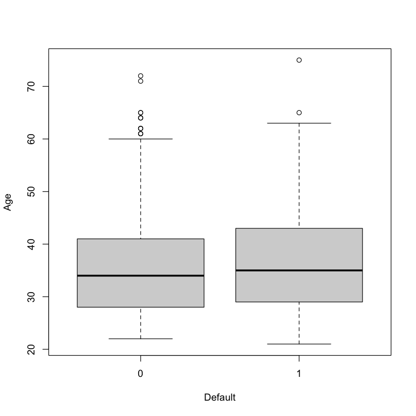

```r
plot(trainSet$default,trainSet$age,xlab = "Default",ylab = "Age")
```

From the plot it can be seen that median values for both 0 and 1 are close each other. However, people who has default is more older. The IQR of the right plot is larger and outliers is more above compared to first plot. It shows that age has effect on model. As age increase, more probably the default is 1

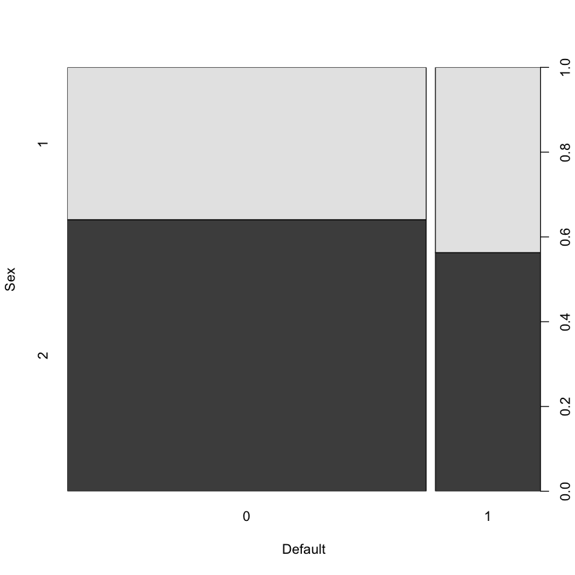

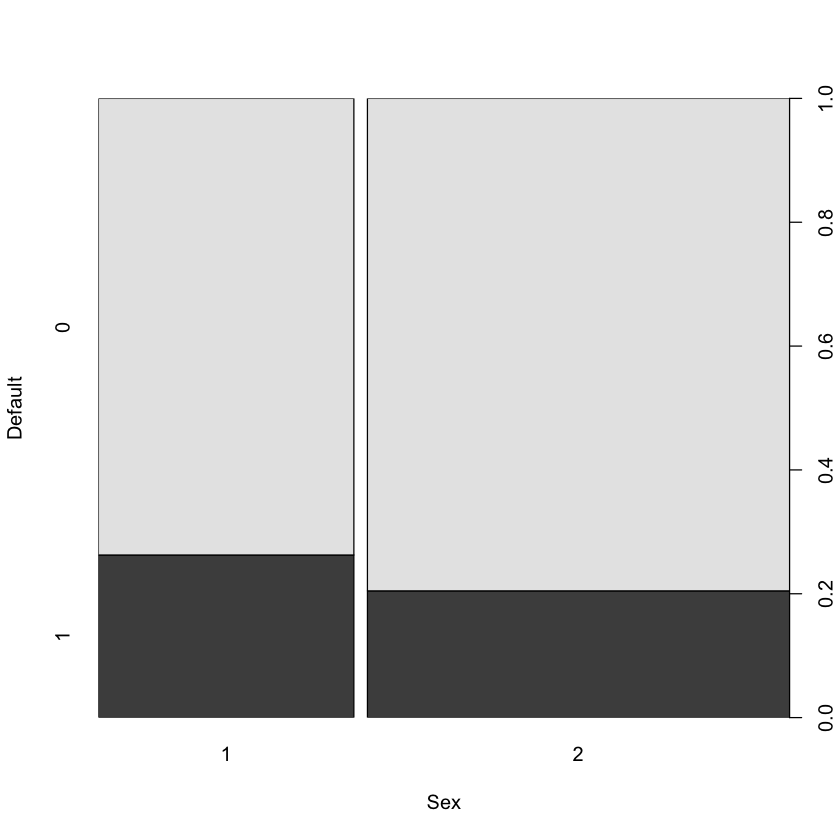

```r
plot(trainSet$default,trainSet$sex,xlab = "Default",ylab = "Sex")
plot(trainSet$sex,trainSet$default,xlab = "Sex",ylab = "Default")
```

It seems there is a relation between sex and default. These plots show that the probability of default of men are higher than women.

```r
install.packages("lmtest")
library(lmtest)
```

```r
#HO : Full model and model without age fit the data equally well
```

```r
model1 = glm(default~.,family= binomial(link = logit),trainSet)
model2 = glm(default~.-age,family= binomial(link = logit),trainSet)
lrtest(model1,model2)
```

A anova: 2 × 5

|  | #Df <dbl> | LogLik <dbl> | Df <dbl> | Chisq <dbl> | Pr(>Chisq) <dbl> |
| --- | --- | --- | --- | --- | --- |
| 1 | 15 | -869.2873 | NA | NA | NA |
| 2 | 14 | -875.1520 | -1 | 11.72941 | 0.0006152012 |

From the LRT we can see that age is signifance. A full model and model without age is considered and from the p-value we reject H0. It says that age effects the output. (For alpha = 0.95)

```r
#HO : Full model and model without sex fit the data equally well
```

```r
model1 = glm(default~.,family= binomial(link = logit),trainSet)
model2 = glm(default~.-sex,family= binomial(link = logit),trainSet)
lrtest(model1,model2)
```

A anova: 2 × 5

|  | #Df <dbl> | LogLik <dbl> | Df <dbl> | Chisq <dbl> | Pr(>Chisq) <dbl> |
| --- | --- | --- | --- | --- | --- |
| 1 | 15 | -869.2873 | NA | NA | NA |
| 2 | 14 | -872.5561 | -1 | 6.53774 | 0.01056094 |

Same comment can also be made here. Sex variable has impact on output.

# Q3

## Data Preparing

```r
load("IQ.RData")
set.seed(2018402189)
IQ <- IQ[sample(1:dim(IQ)[1],250),]
rownames(CC)<-NULL
```

```r
head(IQ,2)
summary(IQ)
```

A data.frame: 2 × 6

|  | IQc <int> | IQv <int> | sex <dbl> | weight <int> | height <dbl> | education <int> |
| --- | --- | --- | --- | --- | --- | --- |
| 734 | 34 | 92 | 1 | 60 | 52.4 | 3 |
| 1295 | 40 | 91 | 1 | 66 | 54.4 | 4 |

```
      IQc            IQv              sex           weight
 Min.   : 9.0   Min.   : 55.00   Min.   :0.00   Min.   : 46.00
 1st Qu.:25.0   1st Qu.: 73.00   1st Qu.:0.00   1st Qu.: 61.00
 Median :31.0   Median : 79.50   Median :0.00   Median : 68.00
 Mean   :31.4   Mean   : 79.51   Mean   :0.46   Mean   : 70.26
 3rd Qu.:39.0   3rd Qu.: 86.00   3rd Qu.:1.00   3rd Qu.: 75.00
 Max.   :52.0   Max.   :128.00   Max.   :1.00   Max.   :142.00
     height        education
 Min.   :46.20   Min.   :0.000
 1st Qu.:51.40   1st Qu.:2.000
 Median :53.50   Median :2.000
 Mean   :53.41   Mean   :2.596
 3rd Qu.:55.10   3rd Qu.:3.000
 Max.   :61.40   Max.   :4.000
```

```r
IQ$sex = as.factor(IQ$sex)
IQ$education = as.factor(IQ$education)
summary(IQ)
```

```
      IQc            IQv         sex         weight           height
 Min.   : 9.0   Min.   : 55.00   0:135   Min.   : 46.00   Min.   :46.20
 1st Qu.:25.0   1st Qu.: 73.00   1:115   1st Qu.: 61.00   1st Qu.:51.40
 Median :31.0   Median : 79.50           Median : 68.00   Median :53.50
 Mean   :31.4   Mean   : 79.51           Mean   : 70.26   Mean   :53.41
 3rd Qu.:39.0   3rd Qu.: 86.00           3rd Qu.: 75.00   3rd Qu.:55.10
 Max.   :52.0   Max.   :128.00           Max.   :142.00   Max.   :61.40
 education
 0:  5
 1: 20
 2:102
 3: 67
 4: 56
```

# Model Selection - Part A

Here, different full models are tried. LM,GLM with poisson and gamma models are compared considering their AIC values. It seems that for this spesific problem lm model fits better than the other.

```r
model_lm = lm(IQc~.,IQ)
summary(model_lm)
AIC(model_lm) #seems best fitting
model_pois = glm(IQc~.,family=poisson(link = sqrt),IQ)
summary(model_pois)
model_poislog = glm(IQc~.,family=poisson(link = log),IQ)
summary(model_poislog)
model_gama = glm(IQc~.,family=Gamma(link = log),IQ)
summary(model_gama)
```

```
Call:
lm(formula = IQc ~ ., data = IQ)

Residuals:
     Min       1Q   Median       3Q      Max
-21.4825  -6.3672  -0.0821   6.2447  26.9467

Coefficients:
            Estimate Std. Error t value Pr(>|t|)
(Intercept)  7.63869   13.87007   0.551 0.582328
IQv          0.38496    0.05346   7.201  7.6e-12 ***
sex1        -3.60264    1.08019  -3.335 0.000987 ***
weight      -0.04232    0.05352  -0.791 0.429905
height      -0.12874    0.30130  -0.427 0.669556
education1   0.50658    4.33954   0.117 0.907166
education2   3.34452    4.01931   0.832 0.406169
education3   6.75815    4.10375   1.647 0.100897
education4   6.42374    4.20754   1.527 0.128142
---
Signif. codes:  0 ‘***’ 0.001 ‘**’ 0.01 ‘*’ 0.05 ‘.’ 0.1 ‘ ’ 1

Residual standard error: 8.345 on 241 degrees of freedom
Multiple R-squared:  0.3074,	Adjusted R-squared:  0.2844
F-statistic: 13.37 on 8 and 241 DF,  p-value: 5.625e-16
```

1781.12497861042

```
Call:
glm(formula = IQc ~ ., family = poisson(link = sqrt), data = IQ)

Deviance Residuals:
    Min       1Q   Median       3Q      Max
-4.0808  -1.2005   0.0016   1.0814   4.8842

Coefficients:
             Estimate Std. Error z value Pr(>|z|)
(Intercept)  3.277732   0.831057   3.944 8.01e-05 ***
IQv          0.034834   0.003203  10.874  < 2e-16 ***
sex1        -0.314478   0.064722  -4.859 1.18e-06 ***
weight      -0.003570   0.003207  -1.113  0.26556
height      -0.010909   0.018053  -0.604  0.54564
education1   0.111800   0.260013   0.430  0.66721
education2   0.403583   0.240826   1.676  0.09377 .
education3   0.705335   0.245885   2.869  0.00412 **
education4   0.666952   0.252104   2.646  0.00816 **
---
Signif. codes:  0 ‘***’ 0.001 ‘**’ 0.01 ‘*’ 0.05 ‘.’ 0.1 ‘ ’ 1

(Dispersion parameter for poisson family taken to be 1)

    Null deviance: 811.72  on 249  degrees of freedom
Residual deviance: 570.49  on 241  degrees of freedom
AIC: 1896.8

Number of Fisher Scoring iterations: 4
```

```
Call:
glm(formula = IQc ~ ., family = poisson(link = log), data = IQ)

Deviance Residuals:
    Min       1Q   Median       3Q      Max
-4.0853  -1.2384  -0.0009   1.0872   4.6525

Coefficients:
             Estimate Std. Error z value Pr(>|z|)
(Intercept)  2.622241   0.300508   8.726  < 2e-16 ***
IQv          0.011690   0.001097  10.660  < 2e-16 ***
sex1        -0.115397   0.023228  -4.968 6.77e-07 ***
weight      -0.001296   0.001166  -1.111  0.26638
height      -0.003966   0.006427  -0.617  0.53717
education1   0.091362   0.112742   0.810  0.41773
education2   0.197723   0.105711   1.870  0.06143 .
education3   0.305748   0.106949   2.859  0.00425 **
education4   0.294504   0.108590   2.712  0.00669 **
---
Signif. codes:  0 ‘***’ 0.001 ‘**’ 0.01 ‘*’ 0.05 ‘.’ 0.1 ‘ ’ 1

(Dispersion parameter for poisson family taken to be 1)

    Null deviance: 811.72  on 249  degrees of freedom
Residual deviance: 575.17  on 241  degrees of freedom
AIC: 1901.5

Number of Fisher Scoring iterations: 4
```

```
Call:
glm(formula = IQc ~ ., family = Gamma(link = log), data = IQ)

Deviance Residuals:
     Min        1Q    Median        3Q       Max
-0.90537  -0.22986   0.00321   0.18098   0.89382

Coefficients:
             Estimate Std. Error t value Pr(>|t|)
(Intercept)  2.526737   0.471630   5.357 1.97e-07 ***
IQv          0.012760   0.001818   7.019 2.26e-11 ***
sex1        -0.110602   0.036730  -3.011  0.00288 **
weight      -0.001208   0.001820  -0.664  0.50758
height      -0.003688   0.010245  -0.360  0.71915
education1   0.067799   0.147559   0.459  0.64631
education2   0.186671   0.136670   1.366  0.17326
education3   0.293838   0.139542   2.106  0.03626 *
education4   0.276734   0.143071   1.934  0.05425 .
---
Signif. codes:  0 ‘***’ 0.001 ‘**’ 0.01 ‘*’ 0.05 ‘.’ 0.1 ‘ ’ 1

(Dispersion parameter for Gamma family taken to be 0.08051603)

    Null deviance: 28.627  on 249  degrees of freedom
Residual deviance: 20.723  on 241  degrees of freedom
AIC: 1805.1

Number of Fisher Scoring iterations: 5
```

After the selection of lm model, its assumptions will be investigated. It seems that residuals have mean around zero and there is no changing variance. Therefore, without doing any changes model will be run. The adjustments of one by one.

```
Call:
lm(formula = IQc ~ ., data = IQ)

Residuals:
     Min       1Q   Median       3Q      Max
-21.4825  -6.3672  -0.0821   6.2447  26.9467

Coefficients:
            Estimate Std. Error t value Pr(>|t|)
(Intercept)  7.63869   13.87007   0.551 0.582328
IQv          0.38496    0.05346   7.201  7.6e-12 ***
sex1        -3.60264    1.08019  -3.335 0.000987 ***
weight      -0.04232    0.05352  -0.791 0.429905
height      -0.12874    0.30130  -0.427 0.669556
education1   0.50658    4.33954   0.117 0.907166
education2   3.34452    4.01931   0.832 0.406169
education3   6.75815    4.10375   1.647 0.100897
education4   6.42374    4.20754   1.527 0.128142
---
Signif. codes:  0 ‘***’ 0.001 ‘**’ 0.01 ‘*’ 0.05 ‘.’ 0.1 ‘ ’ 1

Residual standard error: 8.345 on 241 degrees of freedom
Multiple R-squared:  0.3074,	Adjusted R-squared:  0.2844
F-statistic: 13.37 on 8 and 241 DF,  p-value: 5.625e-16
```

1781.12497861042

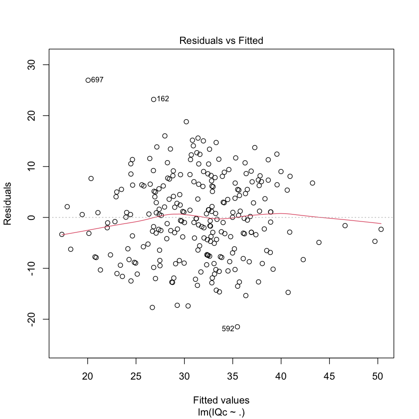

```r
modelLm = lm(IQc~.,IQ)
summary(modelLm)
plot(modelLm,1)
AIC(modelLm)
```

```r
modelLm = lm(IQc~.-height ,IQ)
summary(modelLm)
AIC(modelLm)
```

```
Call:
lm(formula = IQc ~ . - height, data = IQ)

Residuals:
     Min       1Q   Median       3Q      Max
-21.3768  -6.5411   0.1302   6.2651  26.9226

Coefficients:
            Estimate Std. Error t value Pr(>|t|)
(Intercept)  2.28065    5.91717   0.385 0.700258
IQv          0.38369    0.05329   7.200 7.55e-12 ***
sex1        -3.62082    1.07753  -3.360 0.000905 ***
weight      -0.05857    0.03759  -1.558 0.120485
education1   0.32005    4.31022   0.074 0.940870
education2   3.04964    3.95292   0.771 0.441169
education3   6.49688    4.05107   1.604 0.110075
education4   6.14958    4.15130   1.481 0.139811
---
Signif. codes:  0 ‘***’ 0.001 ‘**’ 0.01 ‘*’ 0.05 ‘.’ 0.1 ‘ ’ 1

Residual standard error: 8.331 on 242 degrees of freedom
Multiple R-squared:  0.3069,	Adjusted R-squared:  0.2869
F-statistic: 15.31 on 7 and 242 DF,  p-value: < 2.2e-16
```

1779.31429402199

```r
modelLm = lm(IQc~.-height-weight ,IQ)
summary(modelLm)
AIC(modelLm)
```

```
Call:
lm(formula = IQc ~ . - height - weight, data = IQ)

Residuals:
     Min       1Q   Median       3Q      Max
-21.0014  -6.9092  -0.2247   6.2220  25.7694

Coefficients:
            Estimate Std. Error t value Pr(>|t|)
(Intercept) -2.49498    5.07648  -0.491  0.62353
IQv          0.37440    0.05311   7.050 1.85e-11 ***
sex1        -3.40141    1.07143  -3.175  0.00169 **
education1   1.80973    4.21520   0.429  0.66806
education2   4.28871    3.88348   1.104  0.27053
education3   7.84325    3.96947   1.976  0.04930 *
education4   7.54457    4.06552   1.856  0.06470 .
---
Signif. codes:  0 ‘***’ 0.001 ‘**’ 0.01 ‘*’ 0.05 ‘.’ 0.1 ‘ ’ 1

Residual standard error: 8.355 on 243 degrees of freedom
Multiple R-squared:  0.2999,	Adjusted R-squared:  0.2827
F-statistic: 17.35 on 6 and 243 DF,  p-value: < 2.2e-16
```

1779.81015150977

Here, education values are not removed from the model. Because they increase the AIC values significantly but some of them is significant where some of them are not. Therefore, new columns indicate the education levels are added to the data.

```r
load("IQ.RData")
set.seed(2018402189)
dataAdj <- IQ

dataAdj$Educ1 = rep(0,dim(dataAdj)[1])

dataAdj[dataAdj$education == 1,]$Educ1 = 1


dataAdj$Educ2 = rep(0,dim(dataAdj)[1])

dataAdj[dataAdj$education == 2,]$Educ1 = 1
dataAdj[dataAdj$education == 2,]$Educ2 = 1


dataAdj$Educ3 = rep(0,dim(dataAdj)[1])

dataAdj[dataAdj$education == 3,]$Educ1 = 1
dataAdj[dataAdj$education == 3,]$Educ2 = 1
dataAdj[dataAdj$education == 3,]$Educ3 = 1


dataAdj$Educ4 = rep(0,dim(dataAdj)[1])

dataAdj[dataAdj$education == 4,]$Educ1 = 1
dataAdj[dataAdj$education == 4,]$Educ2 = 1
dataAdj[dataAdj$education == 4,]$Educ3 = 1
dataAdj[dataAdj$education == 4,]$Educ4 = 1


dataAdj$Educ1 = as.factor(dataAdj$Educ1)
dataAdj$Educ2 = as.factor(dataAdj$Educ2)
dataAdj$Educ3 = as.factor(dataAdj$Educ3)
dataAdj$Educ4 = as.factor(dataAdj$Educ4)
dataAdj$sex = as.factor(dataAdj$sex)
dataAdj$education = as.factor(dataAdj$education)
summary(dataAdj)
```

```
      IQc             IQv         sex         weight           height
 Min.   : 8.00   Min.   : 51.00   0:648   Min.   : 45.00   Min.   :46.20
 1st Qu.:23.75   1st Qu.: 72.00   1:648   1st Qu.: 61.00   1st Qu.:51.60
 Median :31.00   Median : 80.00           Median : 68.00   Median :53.30
 Mean   :30.95   Mean   : 79.09           Mean   : 70.94   Mean   :53.46
 3rd Qu.:39.00   3rd Qu.: 85.00           3rd Qu.: 78.00   3rd Qu.:55.20
 Max.   :56.00   Max.   :130.00           Max.   :143.00   Max.   :62.00
 education Educ1    Educ2    Educ3   Educ4
 0: 26     0:  26   0: 127   0:621   0:1005
 1:101     1:1270   1:1169   1:675   1: 291
 2:494
 3:384
 4:291
```

```r
modelLm = lm(IQc~.-education-height-weight-Educ4-Educ1,dataAdj)
summary(modelLm)
AIC(modelLm)
```

```
Call:
lm(formula = IQc ~ . - education - height - weight - Educ4 -
    Educ1, data = dataAdj)

Residuals:
     Min       1Q   Median       3Q      Max
-24.4605  -5.9915   0.2972   6.1371  27.7329

Coefficients:
            Estimate Std. Error t value Pr(>|t|)
(Intercept) -5.52721    1.84115  -3.002  0.00273 **
IQv          0.44362    0.02363  18.774  < 2e-16 ***
sex1        -2.80804    0.47478  -5.914 4.26e-09 ***
Educ21       1.34712    0.83946   1.605  0.10879
Educ31       3.03829    0.51218   5.932 3.84e-09 ***
---
Signif. codes:  0 ‘***’ 0.001 ‘**’ 0.01 ‘*’ 0.05 ‘.’ 0.1 ‘ ’ 1

Residual standard error: 8.379 on 1291 degrees of freedom
Multiple R-squared:  0.2966,	Adjusted R-squared:  0.2944
F-statistic: 136.1 on 4 and 1291 DF,  p-value: < 2.2e-16
```

9194.61361765719

```r
modelLm = lm(IQc~.-education-height-weight-Educ1-Educ4-1,dataAdj)
summary(modelLm)
AIC(modelLm)
```

```
Call:
lm(formula = IQc ~ . - education - height - weight - Educ1 -
    Educ4 - 1, data = dataAdj)

Residuals:
     Min       1Q   Median       3Q      Max
-24.4605  -5.9915   0.2972   6.1371  27.7329

Coefficients:
       Estimate Std. Error t value Pr(>|t|)
IQv     0.44362    0.02363  18.774  < 2e-16 ***
sex0   -5.52721    1.84115  -3.002  0.00273 **
sex1   -8.33525    1.92326  -4.334 1.58e-05 ***
Educ21  1.34712    0.83946   1.605  0.10879
Educ31  3.03829    0.51218   5.932 3.84e-09 ***
---
Signif. codes:  0 ‘***’ 0.001 ‘**’ 0.01 ‘*’ 0.05 ‘.’ 0.1 ‘ ’ 1

Residual standard error: 8.379 on 1291 degrees of freedom
Multiple R-squared:  0.9339,	Adjusted R-squared:  0.9336
F-statistic:  3646 on 5 and 1291 DF,  p-value: < 2.2e-16
```

9194.61361765718

```r
finalModel = lm(IQc~.-education-height-weight-Educ1-Educ4-1,dataAdj)
```

## Part B

```r
notFirst20 =dataAdj[-c(1:20),]
first20 = dataAdj[c(1:20),]
finalModelNotFirst20 = lm(IQc~.-education-height-weight-Educ1-Educ4-1,notFirst20)
```

```r
first20$predictions = predict(finalModelNotFirst20,first20)
first20
mseOutSample = mean((first20$predictions - first20$IQc)^2)
mseOutSample
```

A data.frame: 20 × 11

|  | IQc <int> | IQv <int> | sex <fct> | weight <int> | height <dbl> | education <fct> | Educ1 <fct> | Educ2 <fct> | Educ3 <fct> | Educ4 <fct> | predictions <dbl> |
| --- | --- | --- | --- | --- | --- | --- | --- | --- | --- | --- | --- |
| 1 | 34 | 85 | 0 | 85 | 55.7 | 1 | 1 | 0 | 0 | 0 | 32.06656 |
| 2 | 34 | 74 | 0 | 59 | 48.9 | 3 | 1 | 1 | 1 | 0 | 31.67494 |
| 3 | 25 | 64 | 0 | 70 | 54.9 | 2 | 1 | 1 | 0 | 0 | 24.12372 |
| 4 | 43 | 87 | 0 | 88 | 53.6 | 2 | 1 | 1 | 0 | 0 | 34.28424 |
| 5 | 40 | 87 | 0 | 68 | 53.4 | 2 | 1 | 1 | 0 | 0 | 34.28424 |
| 6 | 37 | 83 | 0 | 93 | 59.9 | 2 | 1 | 1 | 0 | 0 | 32.51720 |
| 7 | 33 | 81 | 0 | 72 | 53.1 | 2 | 1 | 1 | 0 | 0 | 31.63367 |
| 8 | 37 | 74 | 0 | 84 | 52.2 | 2 | 1 | 1 | 0 | 0 | 28.54134 |
| 9 | 21 | 72 | 0 | 68 | 56.8 | 3 | 1 | 1 | 1 | 0 | 30.79141 |
| 10 | 31 | 64 | 0 | 76 | 53.1 | 2 | 1 | 1 | 0 | 0 | 24.12372 |
| 11 | 29 | 72 | 0 | 51 | 49.0 | 1 | 1 | 0 | 0 | 0 | 26.32366 |
| 12 | 38 | 87 | 0 | 59 | 51.9 | 2 | 1 | 1 | 0 | 0 | 34.28424 |
| 13 | 19 | 72 | 0 | 78 | 55.7 | 1 | 1 | 0 | 0 | 0 | 26.32366 |
| 14 | 27 | 78 | 0 | 73 | 53.4 | 2 | 1 | 1 | 0 | 0 | 30.30839 |
| 15 | 35 | 77 | 0 | 60 | 50.3 | 2 | 1 | 1 | 0 | 0 | 29.86663 |
| 16 | 29 | 75 | 0 | 70 | 55.8 | 2 | 1 | 1 | 0 | 0 | 28.98310 |
| 17 | 25 | 71 | 0 | 78 | 55.2 | 2 | 1 | 1 | 0 | 0 | 27.21606 |
| 18 | 20 | 60 | 0 | 106 | 58.8 | 2 | 1 | 1 | 0 | 0 | 22.35668 |
| 19 | 36 | 79 | 0 | 76 | 53.6 | 3 | 1 | 1 | 1 | 0 | 33.88374 |
| 20 | 32 | 63 | 0 | 64 | 53.3 | 0 | 0 | 0 | 0 | 0 | 22.34780 |

28.7611816385173

## Part C

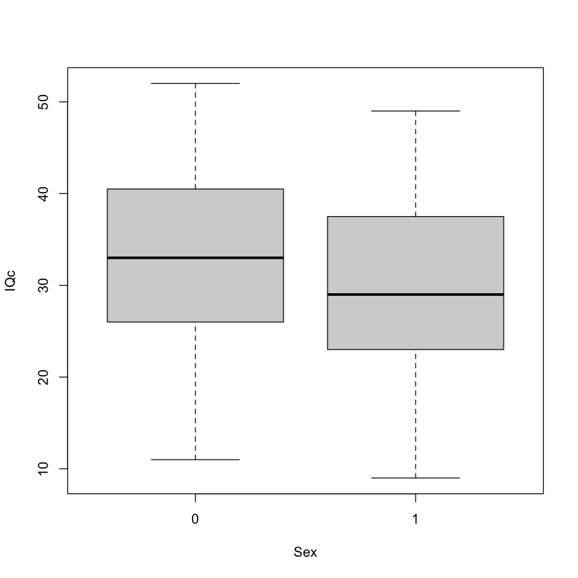

```r
plot(IQ$sex,IQ$IQc,xlab = "Sex",ylab = "IQc")
```

It seems that girls have on average more IQc values than boys. Their upper levels are also higher. So,they are more 'clever'

```r
model1 = lm(IQc~.,IQ)
model2 =lm(IQc~.-sex,IQ)
lrtest(model1,model2)
summary(lm(IQc~sex,IQ))
```

A anova: 2 × 5

|  | #Df <dbl> | LogLik <dbl> | Df <dbl> | Chisq <dbl> | Pr(>Chisq) <dbl> |
| --- | --- | --- | --- | --- | --- |
| 1 | 10 | -880.5625 | NA | NA | NA |
| 2 | 9 | -886.2027 | -1 | 11.28045 | 0.0007832736 |

```
Call:
lm(formula = IQc ~ sex, data = IQ)

Residuals:
     Min       1Q   Median       3Q      Max
-21.6444  -6.6444  -0.2874   7.8911  19.3556

Coefficients:
            Estimate Std. Error t value Pr(>|t|)
(Intercept)  32.6444     0.8427  38.739   <2e-16 ***
sex1         -2.7140     1.2425  -2.184   0.0299 *
---
Signif. codes:  0 ‘***’ 0.001 ‘**’ 0.01 ‘*’ 0.05 ‘.’ 0.1 ‘ ’ 1

Residual standard error: 9.791 on 248 degrees of freedom
Multiple R-squared:  0.01888,	Adjusted R-squared:  0.01492
F-statistic: 4.772 on 1 and 248 DF,  p-value: 0.02987
```

Sex has significant effect on IQc. From lrtest it can be seen. From the Anova results it can be seen that for the sex=1 (boys) the estimation is - It indicates that when the child is boy, its IQc decreases

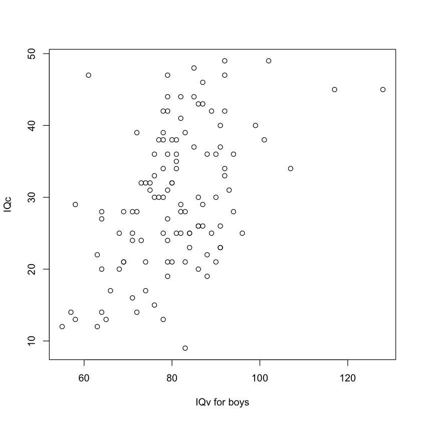

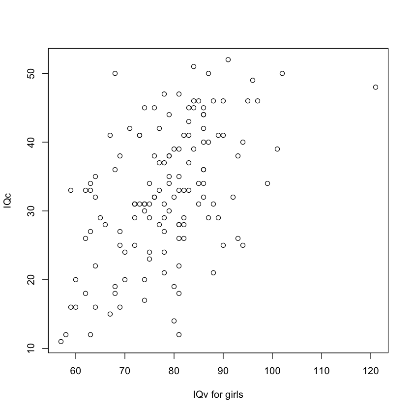

```r
plot(IQ[IQ$sex == 1,]$IQv,IQ[IQ$sex == 1,]$IQc,xlab = "IQv for boys",ylab = "IQc")
plot(IQ[IQ$sex == 0,]$IQv,IQ[IQ$sex == 0,]$IQc,xlab = "IQv for girls",ylab = "IQc")
```

It seems that regardless of the sex, IQc tends to increase as IQv increases.

```r
summary(lm(IQc~IQv,IQ[IQ$sex == 1,]))
summary(lm(IQc~IQv,IQ[IQ$sex == 0,]))
```

```
Call:
lm(formula = IQc ~ IQv, data = IQ[IQ$sex == 1, ])

Residuals:
     Min       1Q   Median       3Q      Max
-21.8305  -6.4003  -0.4552   5.6558  25.0299

Coefficients:
            Estimate Std. Error t value Pr(>|t|)
(Intercept) -2.59743    5.71169  -0.455     0.65
IQv          0.40275    0.07002   5.752 7.66e-08 ***
---
Signif. codes:  0 ‘***’ 0.001 ‘**’ 0.01 ‘*’ 0.05 ‘.’ 0.1 ‘ ’ 1

Residual standard error: 8.583 on 113 degrees of freedom
Multiple R-squared:  0.2265,	Adjusted R-squared:  0.2196
F-statistic: 33.08 on 1 and 113 DF,  p-value: 7.657e-08
```

```
Call:
lm(formula = IQc ~ IQv, data = IQ[IQ$sex == 0, ])

Residuals:
     Min       1Q   Median       3Q      Max
-21.8774  -6.3073   0.4999   6.4298  22.3947

Coefficients:
            Estimate Std. Error t value Pr(>|t|)
(Intercept) -5.20301    5.57587  -0.933    0.352
IQv          0.48247    0.07047   6.847 2.52e-10 ***
---
Signif. codes:  0 ‘***’ 0.001 ‘**’ 0.01 ‘*’ 0.05 ‘.’ 0.1 ‘ ’ 1

Residual standard error: 8.505 on 133 degrees of freedom
Multiple R-squared:  0.2606,	Adjusted R-squared:  0.2551
F-statistic: 46.88 on 1 and 133 DF,  p-value: 2.524e-10
```

From these two models, it can be seen that IQv has significant effect on the IQc and foR both genders it increases IQc. Therefore, it can be said that in both genders IQv and IQc has positive relationship. When IQv increases, also IQc.

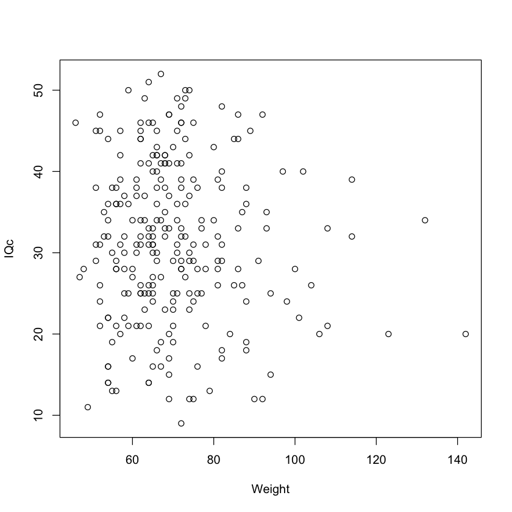

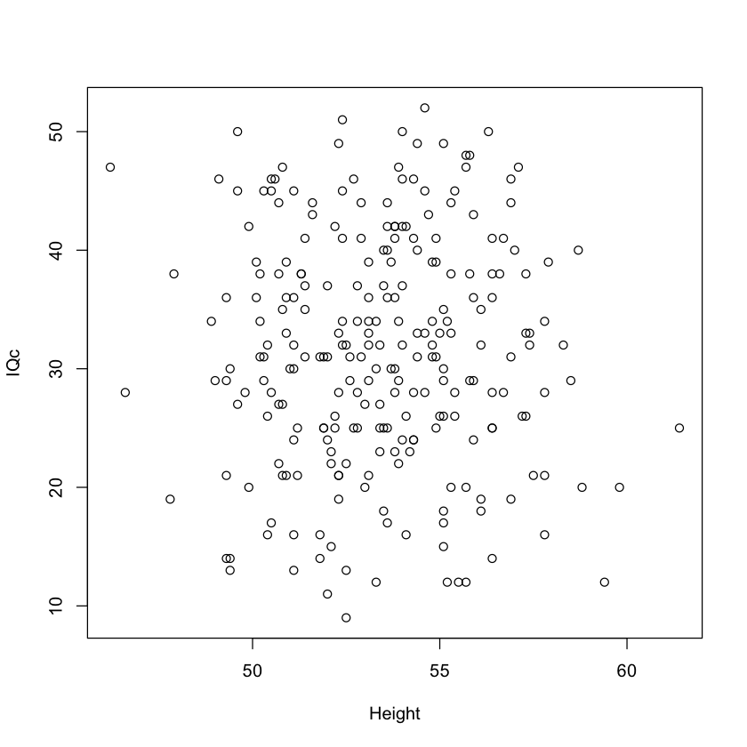

```r
plot(IQ$weight,IQ$IQc,xlab="Weight",ylab = "IQc")
plot(IQ$height,IQ$IQc,xlab = "Height",ylab = "IQc")
```

From graphs, I cannot see a clear effect of height and weight on IQc. It seems that they do not effect on response variable. There is no clear relationship

HO : Full model and model without height fit the data equally well

```r
model1 = lm(IQc~.,IQ)
model2 =lm(IQc~.-height,IQ)
lrtest(model1,model2)
```

A anova: 2 × 5

|  | #Df <dbl> | LogLik <dbl> | Df <dbl> | Chisq <dbl> | Pr(>Chisq) <dbl> |
| --- | --- | --- | --- | --- | --- |
| 1 | 10 | -880.5625 | NA | NA | NA |
| 2 | 9 | -880.6571 | -1 | 0.1893154 | 0.663487 |

```r
#HO : Full model and model without weight fit the data equally well
```

```r
model1 = lm(IQc~.,IQ)
model2 =lm(IQc~.-weight,IQ)
lrtest(model1,model2)
```

A anova: 2 × 5

|  | #Df <dbl> | LogLik <dbl> | Df <dbl> | Chisq <dbl> | Pr(>Chisq) <dbl> |
| --- | --- | --- | --- | --- | --- |
| 1 | 10 | -880.5625 | NA | NA | NA |
| 2 | 9 | -880.8863 | -1 | 0.6476898 | 0.4209398 |

From these two tests,we do not reject H0. It shows us that weight and height do not have effect on IQc.

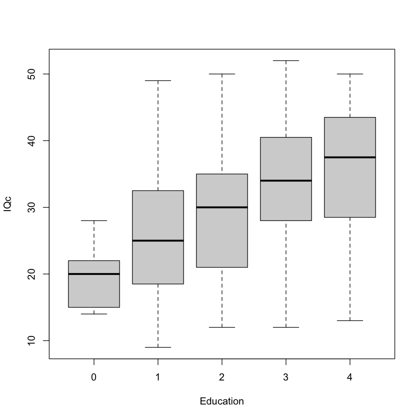

```r
plot(IQ$education,IQ$IQc,xlab = "Education",ylab = "IQc")
```

Clearly, as the education level increases, the IQc level also increases.

```r
summary(lm(IQc~education-1,IQ))
```

```
Call:
lm(formula = IQc ~ education - 1, data = IQ)

Residuals:
     Min       1Q   Median       3Q      Max
-22.6607  -6.5142   0.2696   6.3393  23.2500

Coefficients:
           Estimate Std. Error t value Pr(>|t|)
education0  19.8000     4.1229   4.802 2.73e-06 ***
education1  25.7500     2.0614  12.491  < 2e-16 ***
education2  28.9706     0.9128  31.737  < 2e-16 ***
education3  34.0746     1.1263  30.254  < 2e-16 ***
education4  35.6607     1.2319  28.947  < 2e-16 ***
---
Signif. codes:  0 ‘***’ 0.001 ‘**’ 0.01 ‘*’ 0.05 ‘.’ 0.1 ‘ ’ 1

Residual standard error: 9.219 on 245 degrees of freedom
Multiple R-squared:  0.9231,	Adjusted R-squared:  0.9215
F-statistic: 587.9 on 5 and 245 DF,  p-value: < 2.2e-16
```

Output of the model tells that as the education level increases, it has incremental effect on response variable. Again, the intercept value is omitted with the same reason indicated before.